# Multiple Linear Regression Modelling

## 7. Data Modeling

### 7.1 Hypothesis testing

As the first step of modeling, the hypotheses of this study were set. The modeling process was conducted in the pur-pose of hypothesis testing. Null Hypothesis: There’s no significant relationship between wine quality and the physicochemical properties of the observations. Alternative Hypothesis: There’s a significant relationship between wine quality and the physicochemical properties of the observations.

#### 7.2. Assumptions

##### 7.2.1 Additivity Assumption

```r
#symnum correlation table
correlation <- cor(wine_data_transformed)#correlation matrix
print(correlation)
```

```
##                      fixed.acidity volatile.acidity citric.acid residual.sugar
## fixed.acidity           1.00000000      -0.27284761  0.68579768     0.17067236
## volatile.acidity       -0.27284761       1.00000000 -0.59198225     0.07404863
## citric.acid             0.68579768      -0.59198225  1.00000000     0.15985866
## residual.sugar          0.17067236       0.07404863  0.15985866     1.00000000
## chlorides               0.20701559       0.15755468  0.10398586     0.16435623
## free.sulfur.dioxide    -0.17075848       0.02151416 -0.09421987     0.05197507
## total.sulfur.dioxide   -0.10672991       0.09855208 -0.01542183     0.11574080
## density                 0.67161362       0.05088358  0.36198172     0.37433558
## pH                     -0.73229119       0.22988022 -0.54272436    -0.07406816
## sulphates               0.21046507      -0.33931111  0.32487755     0.04617572
## alcohol                -0.09805672      -0.24059095  0.12424654     0.10548541
## quality                 0.11762681      -0.39266170  0.24402001     0.02111999
##                        chlorides free.sulfur.dioxide total.sulfur.dioxide
## fixed.acidity         0.20701559         -0.17075848        -0.1067299062
## volatile.acidity      0.15755468          0.02151416         0.0985520792
## citric.acid           0.10398586         -0.09421987        -0.0154218326
## residual.sugar        0.16435623          0.05197507         0.1157407960
## chlorides             1.00000000         -0.03868337         0.0888487886
## free.sulfur.dioxide  -0.03868337          1.00000000         0.7885751933
## total.sulfur.dioxide  0.08884879          0.78857519         1.0000000000
## density               0.38644880         -0.04118428         0.1226492159
## pH                   -0.21673807          0.11163879         0.0000323701
## sulphates             0.06426352          0.04477346         0.0158048167
## alcohol              -0.29474185         -0.09477584        -0.2762382160
## quality              -0.16932773         -0.05157649        -0.1792004890
##                          density            pH   sulphates     alcohol
## fixed.acidity         0.67161362 -0.7322911865  0.21046507 -0.09805672
## volatile.acidity      0.05088358  0.2298802189 -0.33931111 -0.24059095
## citric.acid           0.36198172 -0.5427243555  0.32487755  0.12424654
## residual.sugar        0.37433558 -0.0740681620  0.04617572  0.10548541
## chlorides             0.38644880 -0.2167380724  0.06426352 -0.29474185
## free.sulfur.dioxide  -0.04118428  0.1116387944  0.04477346 -0.09477584
## total.sulfur.dioxide  0.12264922  0.0000323701  0.01580482 -0.27623822
## density               1.00000000 -0.3518885836  0.14970542 -0.52212760
## pH                   -0.35188858  1.0000000000 -0.07414704  0.19518068
## sulphates             0.14970542 -0.0741470389  1.00000000  0.22196610
## alcohol              -0.52212760  0.1951806803  0.22196610  1.00000000
## quality              -0.19409755 -0.0629942463  0.37833251  0.50666395
##                          quality
## fixed.acidity         0.11762681
## volatile.acidity     -0.39266170
## citric.acid           0.24402001
## residual.sugar        0.02111999
## chlorides            -0.16932773
## free.sulfur.dioxide  -0.05157649
## total.sulfur.dioxide -0.17920049
## density              -0.19409755
## pH                   -0.06299425
## sulphates             0.37833251
## alcohol               0.50666395
## quality               1.00000000
```

```r
symnum(correlation,symbols = c("| ", ".", ",", "+", "*", "B"))# B represents strongest correlation,  | represents weakest correlation
```

```
##                      fx. v  c. r  ch f.. t  d  p  s  a q
## fixed.acidity        1
## volatile.acidity     |   1
## citric.acid          ,   .  1
## residual.sugar       |   |  |  1
## chlorides            |   |  |  |  1
## free.sulfur.dioxide  |   |  |  |  |  1
## total.sulfur.dioxide |   |  |  |  |  ,   1
## density              ,   |  .  .  .  |   |  1
## pH                   ,   |  .  |  |  |   |  .  1
## sulphates            |   .  .  |  |  |   |  |  |  1
## alcohol              |   |  |  |  |  |   |  .  |  |  1
## quality              |   .  |  |  |  |   |  |  |  .  . 1
## attr(,"legend")
## [1] 0 '| ' 0.3 '.' 0.6 ',' 0.8 '+' 0.9 '*' 0.95 'B' 1
```

##### 7.2.2 Linearity assumption

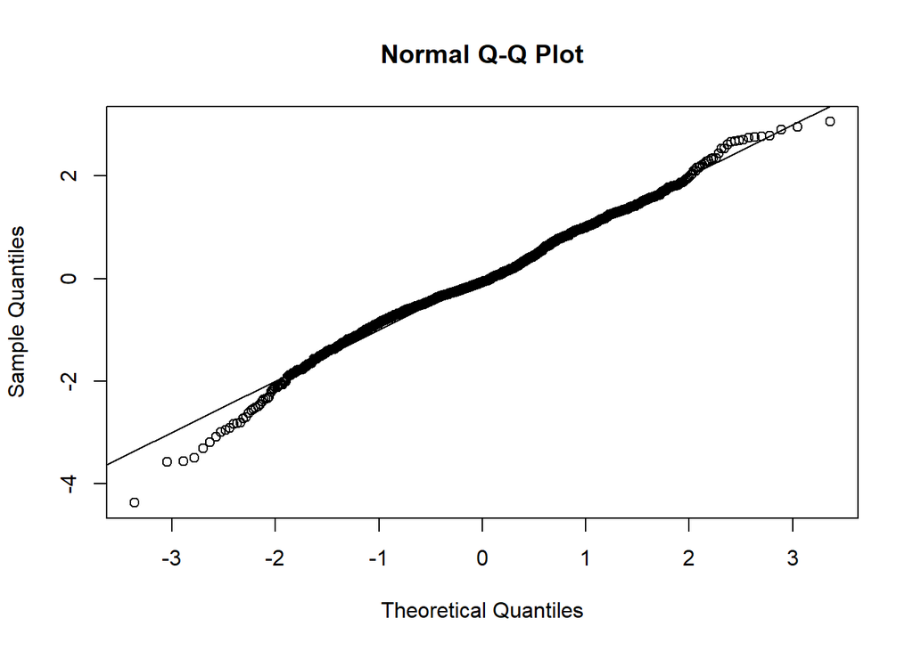

```r
mod_3 <- lm(quality ~ ., data = wine_data_transformed)
#Assumption Set Up
standardized <- rstudent(mod_3)
fitted <- scale(mod_3$fitted.values)#

{qqnorm(standardized)
  abline(0,1)}
```

The assumption for linearity is met, the data points follows the reference line, only the points at two ends (below -2 and above 2) deviate

##### 7.2.3 Normality Assumption

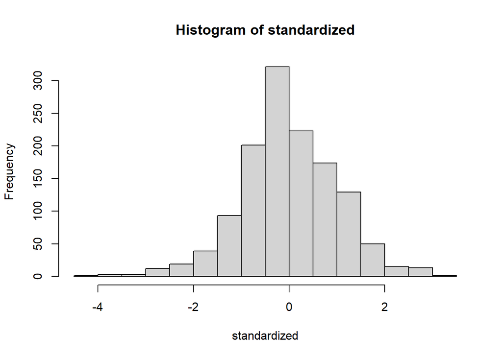

```r
hist(standardized)
```

The assumption for normality is met, the histogram shows a bell curve shape indicating the data are approximately normal distributed/

##### 7.2.4 Homogeneity and Homoscedasticity Assumption

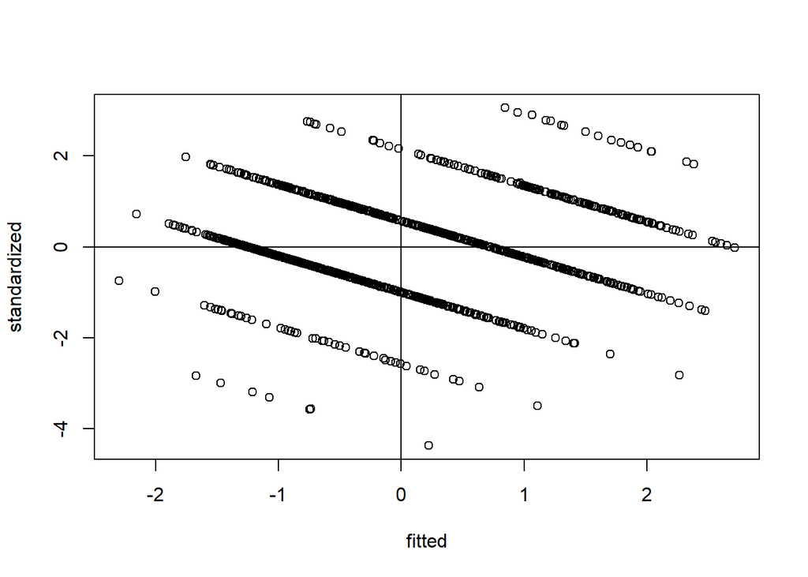

```r
{plot(fitted, standardized)
  abline(0,0)
  abline(v = 0)}
```